# Data Vis and Reproducibility

2022-12-03

## Precursors & Data Preparation

Loading required packages:

```r
source("functions/libraries.r")
```

Unaltered copy of data set put aside in folder:

```r
write.csv(penguins_raw, "data_raw/penguins_raw.csv")
penguins_raw <- read.csv("data_raw/penguins_raw.csv")
knitr::kable(head(penguins_raw))
```

| X | studyName | Sample.Number | Species | Region | Island | Stage | Individual.ID | Clutch.Completion | Date.Egg | Culmen.Length..mm. | Culmen.Depth..mm. | Flipper.Length..mm. | Body.Mass..g. | Sex | Delta.15.N..o.oo. | Delta.13.C..o.oo. | Comments |
| --- | --- | --- | --- | --- | --- | --- | --- | --- | --- | --- | --- | --- | --- | --- | --- | --- | --- |
| 1 | PAL0708 | 1 | Adelie Penguin (Pygoscelis adeliae) | Anvers | Torgersen | Adult, 1 Egg Stage | N1A1 | Yes | 2007-11-11 | 39.1 | 18.7 | 181 | 3750 | MALE | NA | NA | Not enough blood for isotopes. |
| 2 | PAL0708 | 2 | Adelie Penguin (Pygoscelis adeliae) | Anvers | Torgersen | Adult, 1 Egg Stage | N1A2 | Yes | 2007-11-11 | 39.5 | 17.4 | 186 | 3800 | FEMALE | 8.94956 | -24.69454 | NA |
| 3 | PAL0708 | 3 | Adelie Penguin (Pygoscelis adeliae) | Anvers | Torgersen | Adult, 1 Egg Stage | N2A1 | Yes | 2007-11-16 | 40.3 | 18.0 | 195 | 3250 | FEMALE | 8.36821 | -25.33302 | NA |
| 4 | PAL0708 | 4 | Adelie Penguin (Pygoscelis adeliae) | Anvers | Torgersen | Adult, 1 Egg Stage | N2A2 | Yes | 2007-11-16 | NA | NA | NA | NA | NA | NA | NA | Adult not sampled. |
| 5 | PAL0708 | 5 | Adelie Penguin (Pygoscelis adeliae) | Anvers | Torgersen | Adult, 1 Egg Stage | N3A1 | Yes | 2007-11-16 | 36.7 | 19.3 | 193 | 3450 | FEMALE | 8.76651 | -25.32426 | NA |
| 6 | PAL0708 | 6 | Adelie Penguin (Pygoscelis adeliae) | Anvers | Torgersen | Adult, 1 Egg Stage | N3A2 | Yes | 2007-11-16 | 39.3 | 20.6 | 190 | 3650 | MALE | 8.66496 | -25.29805 | NA |

The data need cleaning for ease of use in R. Clean data deposited within its own folder.

```r
source("functions/cleaning.r")
penguins_clean <- cleaning(penguins_raw)
write.csv(penguins_clean, "data_clean/penguins_clean.csv")
knitr::kable(head(penguins_clean))
```

| x | study_name | sample_number | species | region | island | stage | individual_id | clutch_completion | date_egg | culmen_length_mm | culmen_depth_mm | flipper_length_mm | body_mass_g | sex |
| --- | --- | --- | --- | --- | --- | --- | --- | --- | --- | --- | --- | --- | --- | --- |
| 1 | PAL0708 | 1 | Adelie Penguin (Pygoscelis adeliae) | Anvers | Torgersen | Adult, 1 Egg Stage | N1A1 | Yes | 2007-11-11 | 39.1 | 18.7 | 181 | 3750 | MALE |
| 2 | PAL0708 | 2 | Adelie Penguin (Pygoscelis adeliae) | Anvers | Torgersen | Adult, 1 Egg Stage | N1A2 | Yes | 2007-11-11 | 39.5 | 17.4 | 186 | 3800 | FEMALE |
| 3 | PAL0708 | 3 | Adelie Penguin (Pygoscelis adeliae) | Anvers | Torgersen | Adult, 1 Egg Stage | N2A1 | Yes | 2007-11-16 | 40.3 | 18.0 | 195 | 3250 | FEMALE |
| 4 | PAL0708 | 4 | Adelie Penguin (Pygoscelis adeliae) | Anvers | Torgersen | Adult, 1 Egg Stage | N2A2 | Yes | 2007-11-16 | NA | NA | NA | NA | NA |
| 5 | PAL0708 | 5 | Adelie Penguin (Pygoscelis adeliae) | Anvers | Torgersen | Adult, 1 Egg Stage | N3A1 | Yes | 2007-11-16 | 36.7 | 19.3 | 193 | 3450 | FEMALE |
| 6 | PAL0708 | 6 | Adelie Penguin (Pygoscelis adeliae) | Anvers | Torgersen | Adult, 1 Egg Stage | N3A2 | Yes | 2007-11-16 | 39.3 | 20.6 | 190 | 3650 | MALE |

## Analysis of covariance test

In Adelie Penguins, does the relationship between body mass (covariate) and culmen depth (response variable) differ between sexes?

**Hypotheses** (null): - Main effect of sex: mean values of sexes are not significantly different from each other - Body mass: slope of body mass against culmen depth not different from 0 - Interaction: effect of sex not dependent on body mass for culmen depth (and effect of body mass not dependent on sex)

**Preparing the data** (Adelie only, and NA values for Sex removed):

```r
source("functions/cleaning.r")
Adelie <- Adelie_Clean(penguins_clean)
write.csv(Adelie, "data_ANCOVA/Adelie.csv")
```

**Fitting a linear model** (including interaction between sex and body mass):

```r
AdelieMod <- lm(culmen_depth_mm ~ sex * body_mass_g, Adelie)
```

**Assumptions**:

- random sampling (assumed to be met in Palmer Penguins dataset)
- approximate normality of residuals for each independent variable category
- equal variance of response variable for each explanatory variable combination.

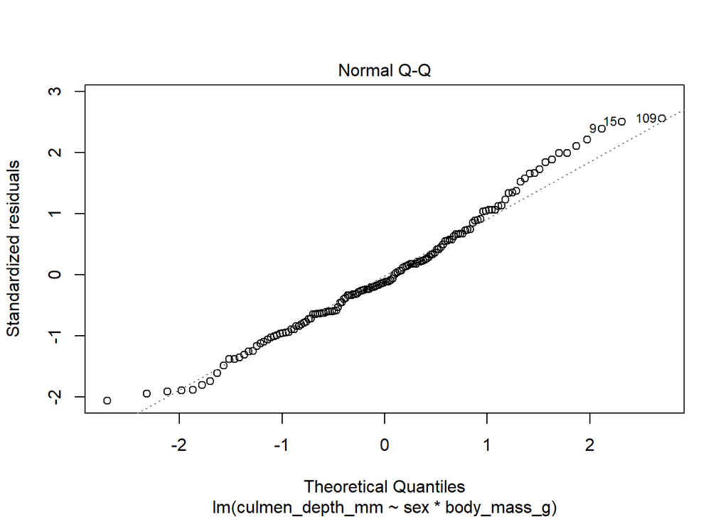

```r
plot(AdelieMod, which = 2)
```

Whilst there is deviation from the line representing normal distribution of data (particularly in the right of the plot), the histogram below demonstrates the data are sufficiently normal for ANCOVA, which is relatively robust to violations of normality assumptions.

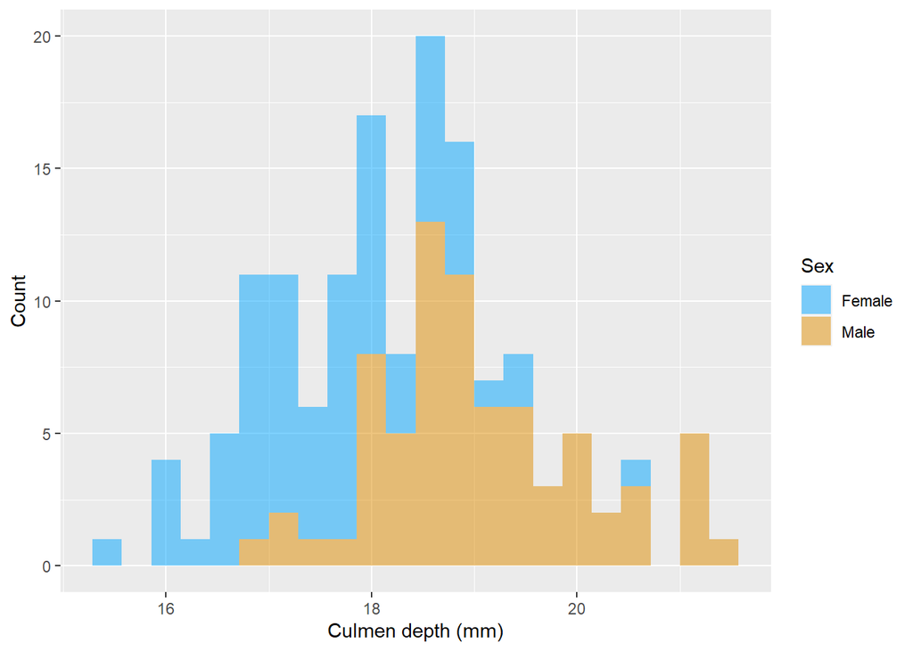

```r
ggplot(Adelie, aes(y = culmen_depth_mm, fill = sex)) + geom_histogram(alpha=0.5, bins=22) + coord_flip() + labs(x= "Count", y = "Culmen depth (mm)") + scale_fill_discrete(name="Sex", labels=c('Female', 'Male'), h = c(245, 45))
```

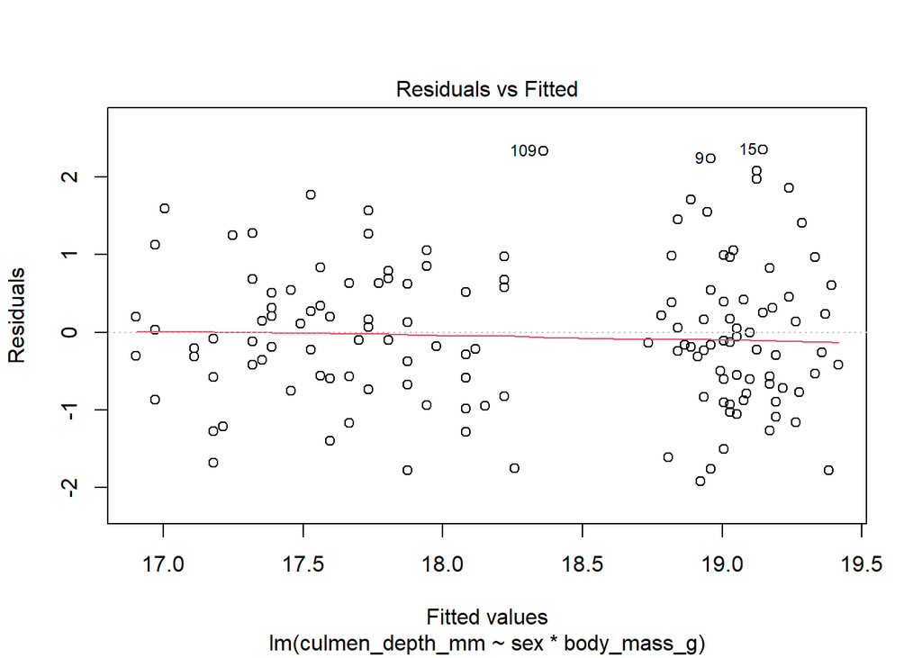

```r
plot(AdelieMod, which = 1)
```

There are very few extreme outliers, and although there is a small deviation from the line representing equality of variance on the right hand side, there is no significant difference in variance between the male and female levels of the sex factor:

```r
x <- subset(Adelie, sex=="MALE")
y <- subset(Adelie, sex=="FEMALE")
var.test(x$culmen_depth_mm, y$culmen_depth_mm, alternative = "two.sided")
```

```
##
##  F test to compare two variances
##
## data:  x$culmen_depth_mm and y$culmen_depth_mm
## F = 1.1674, num df = 72, denom df = 72, p-value = 0.513
## alternative hypothesis: true ratio of variances is not equal to 1
## 95 percent confidence interval:
##  0.7328362 1.8597799
## sample estimates:
## ratio of variances
##           1.167439
```

```r
summary(AdelieMod)
```

```
##
## Call:
## lm(formula = culmen_depth_mm ~ sex * body_mass_g, data = Adelie)
##
## Residuals:
##     Min      1Q  Median      3Q     Max
## -1.9233 -0.6038 -0.1116  0.5700  2.3540
##
## Coefficients:
##                       Estimate Std. Error t value Pr(>|t|)
## (Intercept)         12.9408522  1.3969906   9.263 2.86e-16 ***
## sexMALE              4.2363186  1.9103436   2.218 0.028173 *
## body_mass_g          0.0013895  0.0004134   3.361 0.000997 ***
## sexMALE:body_mass_g -0.0009208  0.0005234  -1.759 0.080716 .
## ---
## Signif. codes:  0 '***' 0.001 '**' 0.01 '*' 0.05 '.' 0.1 ' ' 1
##
## Residual standard error: 0.9449 on 142 degrees of freedom
## Multiple R-squared:  0.4119, Adjusted R-squared:  0.3995
## F-statistic: 33.16 on 3 and 142 DF,  p-value: 2.641e-16
```

**Figure**:

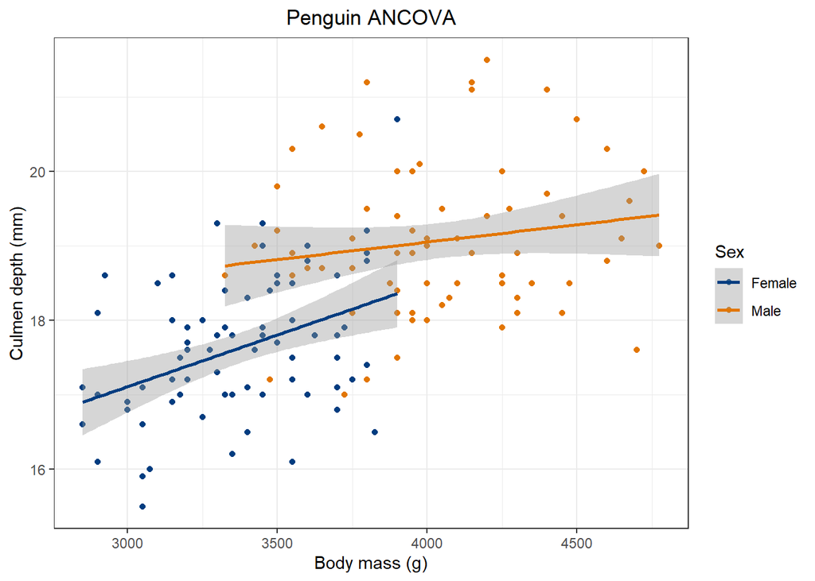

```r
source("functions/plot.r")
PenguinANCOVA <- plot_penguin(Adelie)
PenguinANCOVA
```

Saving figures:

```r
source("functions/plot.r")
save_ANCOVA_png(Adelie, "figures/Fig1.png",
                      width=20, height=15, res=600, scaling=1)

save_ANCOVA_png(Adelie, "figures/Fig2_powerpoint.png",
                      width=20, height=15, res=600, scaling=1.8)

save_ANCOVA_svg(Adelie, "figures/Fig1.svg", width=20, height=15, scaling=2.54)

save_ANCOVA_svg(Adelie, "figures/Fig2_powerpointposter.svg", width=20, height=15, scaling=4.57)
```

**Interpretation**

The i) y intercept for the regression line for the female level in the sex factor, ii) difference in y intercepts between male and female level regression lines and iii) slope of the female level regression line, are all significantly different to 0 at the 0.05 level or below. The difference in slope between the two lines (i.e. interaction) is not significantly different to 0 at the 0.05 level but is at 0.1. Given the non-significance at this level of the interaction term, it could be argued that a (simpler) model without an interaction term would be more suitable. Grey shading on the figure shows 95% confidence interval. However, we should not interpret these P values as a binary construct, and the faint signal of interaction means the main effects should be interpreted with caution. In biological terms (according to the figure and summary table), sex affects culmen depth (males have larger culmen depths - orange line is higher on figure) and increased body mass is related to increased culmen depth but there is not an interaction effect between body mass and sex.